# PRESENTACIÓN NETFLIX

## Presentación del proyecto

## Presentación del proyecto

Netflix nos ha contratado para realizar un modelo de machine learning que sea capaz de recomendar películas en función de los gustos de usuarios.

En esta presentación explicaremos todo el proceso que hemos realizado hasta conseguir el modelo.

Netflix nos ha proporcionado varios archivos de datos.

## Presentación del proyecto

El primero de estos es el documento llamado “movie title.csv”. En este archivo encontramos todos los títulos de todas las películas que se encuentran en esta plataforma, además de su año de estreno y un identificador propio. En total hay 17.770 films distintos.

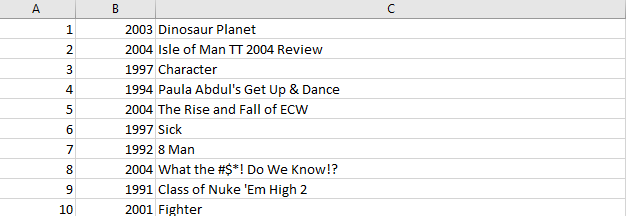

## Presentación del proyecto

Por otro lado, tenemos 4 archivos los cuales contienen para cada película todas sus valoraciones.

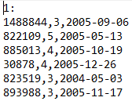

## Presentación del proyecto

Por último, el archivo “filas_ID_combined_all.txt”, donde vemos cada metraje donde tiene sus valoraciones.

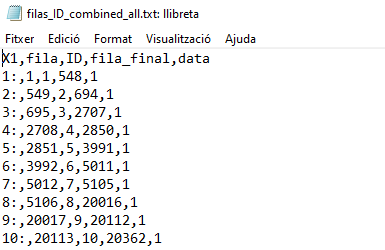

## Ingesta de datos

## Ingesta de datos

Escogemos una muestra de 250 filas del fichero “filas_ID_combined_all” en base a la semilla generada por nuestros DNI.

```r
set.seed(23307791)
muestra_grupo=sample(1:17770,250, replace=FALSE)
head(muestra_grupo)
```

```
## [1]  5217  3157  5347  3858  3237 17638
```

## Ingesta de datos

Separamos las películas en función del fichero en el que estaban. Al hacer esto obtenemos 4 tablas que tienen la siguiente información:

```r
head(muestra_data1)
```

```
## # A tibble: 6 x 5
##   X1        fila    ID fila_final  data
##   <chr>    <dbl> <dbl>      <dbl> <dbl>
## 1 3157: 16356255  3157   16356968     1
## 2 3858: 20154315  3858   20161648     1
## 3 3237: 16664785  3237   16667097     1
## 4 3686: 19398084  3686   19400260     1
## 5 1750:  8788561  1750    8788675     1
## 6 2099: 10677090  2099   10677529     1
```

## Ingesta de datos

Para cada una de estas tablas, miramos las filas donde estaban las valoraciones de cada película y las escribíamos en muestra películas con el siguiente formato:

```r
head(netflix)
```

```
## # A tibble: 6 x 1
##   X1
##   <chr>
## 1 3157:
## 2 2040014,4,2004-05-19
## 3 313627,1,2005-02-04
## 4 115498,4,2002-02-04
## 5 2251405,1,2004-09-10
## 6 617861,4,2003-09-09
```

## Modelo de datos

## Modelo de datos

Es necesario crear una o varias tablas con un formato apropiado para poder tratar los datos correctamente. A lo largo del análisis se crean diversas tablas, pero la principal es la tabla “netflix”.

```
## # A tibble: 6 x 4
##   ID_user Score date       ID_film
##   <chr>   <int> <chr>        <dbl>
## 1 2040014     4 2004-05-19    3157
## 2 313627      1 2005-02-04    3157
## 3 115498      4 2002-02-04    3157
## 4 2251405     1 2004-09-10    3157
## 5 617861      4 2003-09-09    3157
## 6 801523      5 2005-06-17    3157
```

## Modelo de datos

Para poder identificar de que película se trata, añadiremos a la tabla anterior el respectivo título a cada fila.

```
## # A tibble: 6 x 6
##   ID_user Score date       ID_film  year title
##   <chr>   <int> <chr>        <dbl> <int> <chr>
## 1 2040014     4 2004-05-19    3157  1964 I Am Cuba
## 2 313627      1 2005-02-04    3157  1964 I Am Cuba
## 3 115498      4 2002-02-04    3157  1964 I Am Cuba
## 4 2251405     1 2004-09-10    3157  1964 I Am Cuba
## 5 617861      4 2003-09-09    3157  1964 I Am Cuba
## 6 801523      5 2005-06-17    3157  1964 I Am Cuba
```

## Modelo de datos

Cambiamos el tipo de dato de los atributos:

```
## # A tibble: 6 x 6
##   ID_user Score date       ID_film  year title
##   <fct>   <int> <date>     <fct>   <int> <fct>
## 1 2040014     4 2004-05-19 3157     1964 I Am Cuba
## 2 313627      1 2005-02-04 3157     1964 I Am Cuba
## 3 115498      4 2002-02-04 3157     1964 I Am Cuba
## 4 2251405     1 2004-09-10 3157     1964 I Am Cuba
## 5 617861      4 2003-09-09 3157     1964 I Am Cuba
## 6 801523      5 2005-06-17 3157     1964 I Am Cuba
```

## Análisis exploratorio de los datos

## Análisis exploratorio de los datos

Creamos una tabla donde para cada película tenemos la cantidad de valoraciones, la media, la desviación estándar, etc.

```
## # A tibble: 6 x 7
##   ID_film count   sum  mean    sd median  mode
##     <dbl> <int> <int> <dbl> <dbl>  <dbl> <int>
## 1      27   273   963  3.53 1.22       4     4
## 2     128   417  1341  3.22 1.30       3     4
## 3     342  1358  5029  3.70 1.20       4     4
## 4     395  1822  7266  3.99 0.864      4     4
## 5     650   439  1175  2.68 1.20       3     3
## 6     697   209   687  3.29 1.30       4     4
```

## Análisis exploratorio de los datos

Netflix está interesado en películas actuales, pero también tiene un pequeño repertorio de películas clásicas.

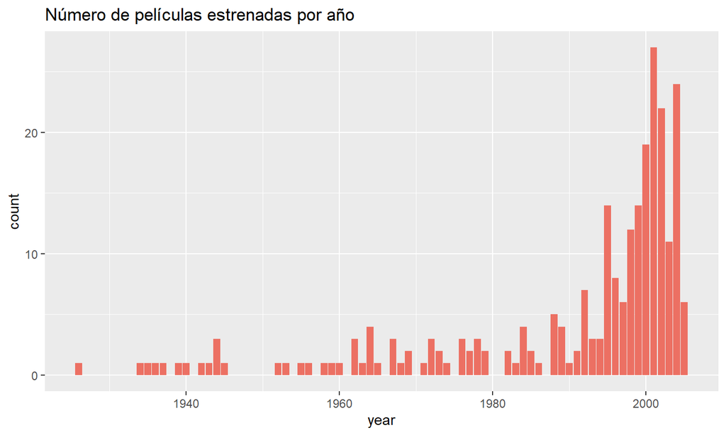

## Análisis exploratorio de los datos

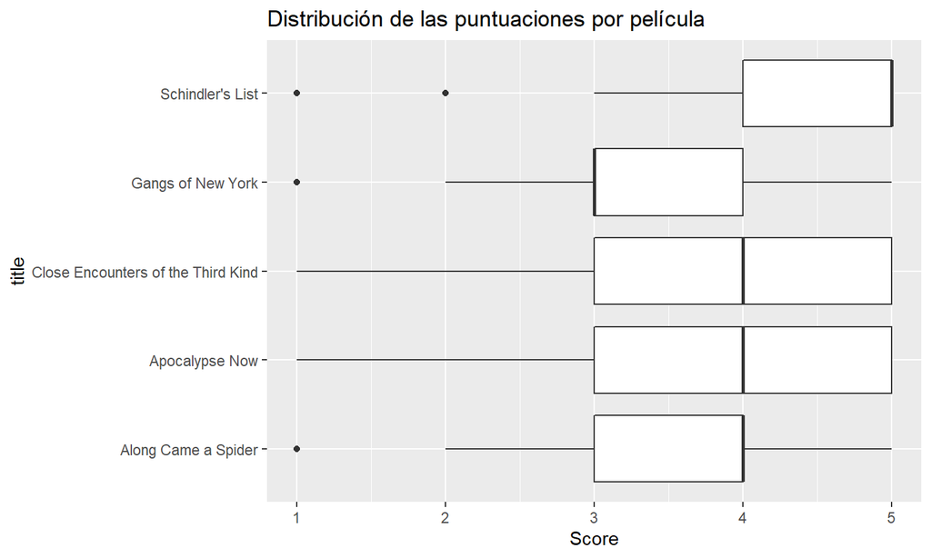

## Análisis exploratorio de los datos

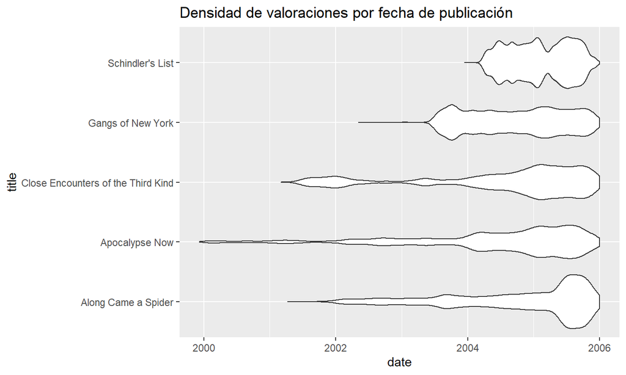

## Análisis exploratorio de los datos

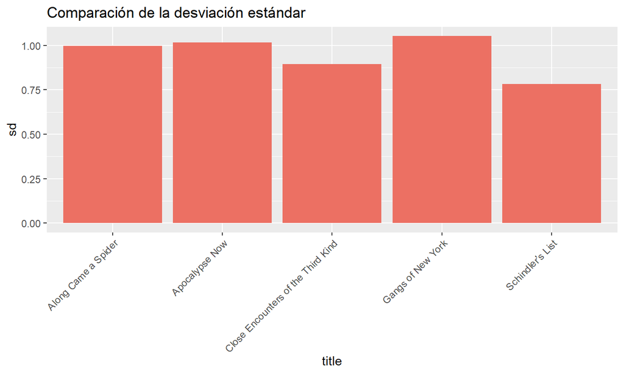

## Análisis exploratorio de los datos

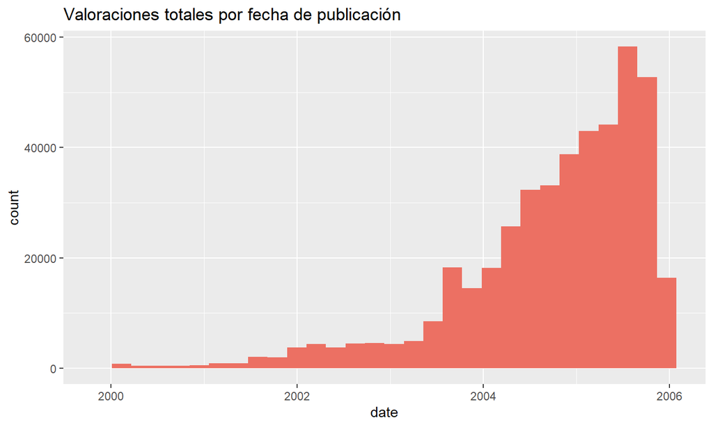

## Análisis exploratorio de los datos

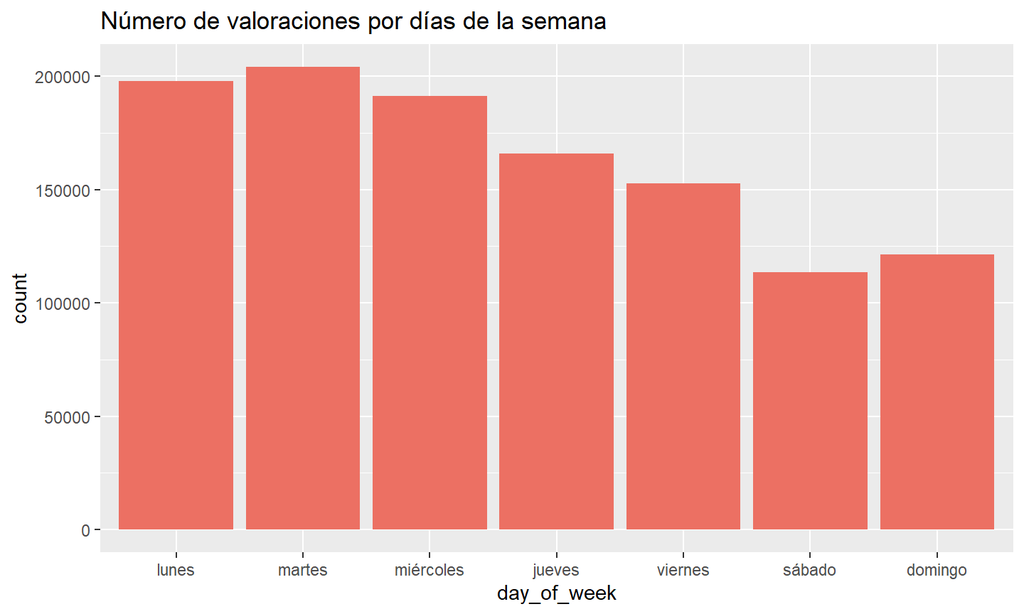

## Análisis exploratorio de los datos

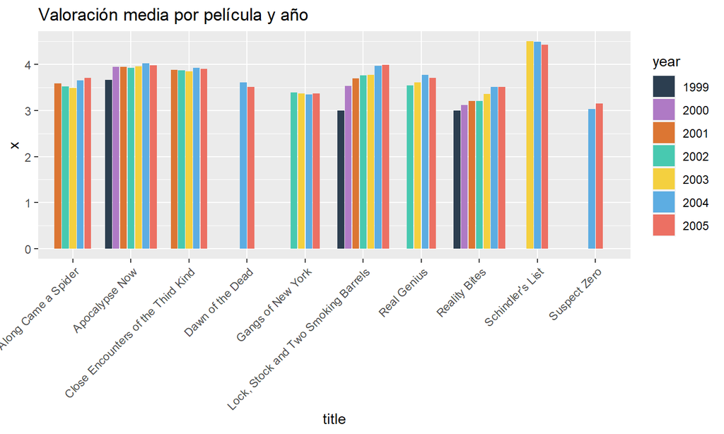

## Análisis exploratorio de los datos

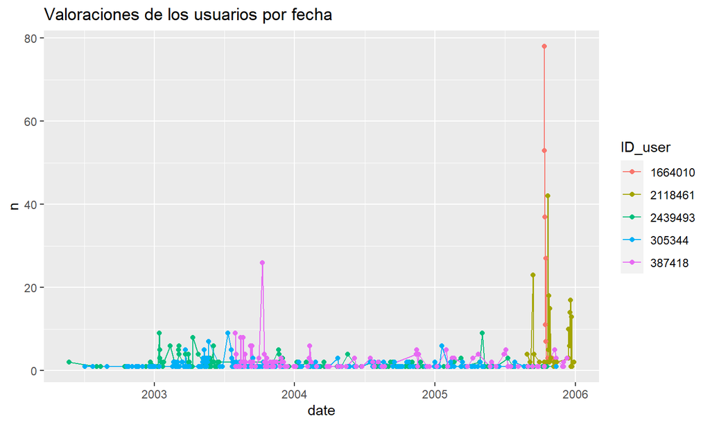

## Clustering

## Sistema de recomendación

Objetivo: agrupar usuarios en clusters en base a sus valoraciones.

A un usuario se le recomendarán películas a las que un usuario de su mismo cluster ha dado una buena valoración.

## Distancia entre usuarios

Cada entrada del cluster representa un usuario. De esta manera se podrá calcular la distancia entre los usuarios.

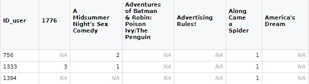

Reducimos la muestra de 310.843 a 10.000 usuarios.

## Clustering - resultado

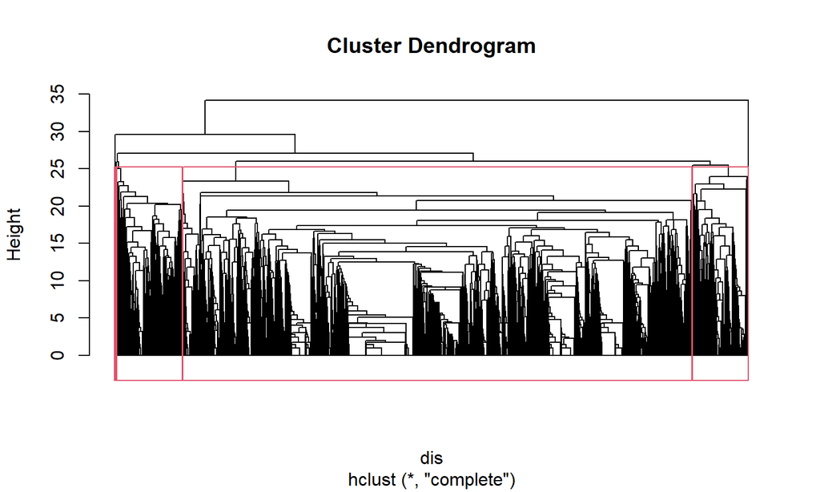

## Limitaciones de nuestro modelo

- Fechas no representativas
- Falta de valoraciones por usuario
- Problemas computacionales (muestra reducida)

## Conclusiones

Los resultados no son los esperados.

Necesitamos más información para poder aplicar técnicas de clustering más eficaces.

Prometemos mejores resultados.